# Project Proposal

### Type of study

This study is observational as no factor levels or controls were put in place, just an observation of self-control and behavior execution ratings.

### Data Source

The source of this data collection is from [A Longitudinal Field Study on the Role of Self-Control in Habit Formation](https://www.frontiersin.org/articles/10.3389/fpsyg.2020.00560/full), with a full citation at the end of this proposal. It involved the following authors Anouk van der Weiden, Jeroen Benjamins, Marleen Gillebaart, Jan Fekke Ybema, and Denise de Ridder.

### Dependent Variable

The dependent variable in this study is habit strength as a quantitative variable*******

### Independent Variable(s)

Independent variables in this study were an individuals self-control capacity and goal-congruent behavior.

### Summary Statistics

```r
## Daily Habit COunts
sdQ1 <- sd(dailyCounts1$n)

minQ1 <- min(dailyCounts1$n)

maxQ1 <- max(dailyCounts1$n)

q25 <- quantile(dailyCounts1$n)

print(paste('The average number of times a participant reported they had performed their daily behavior as completed in question 1 was', round(meanQ1, digits =2), 'with a standard deviation of',round(sdQ1, digits =2),', a minimum of', minQ1,'a max of ',maxQ1,', and the following quantiles: ',q25[1],q25[2],q25[3],q25[4],q25[5],'.'))
```

```
## [1] "The average number of times a participant reported they had performed their daily behavior as completed in question 1 was 39.92 with a standard deviation of 27.84 , a minimum of 1 a max of  116 , and the following quantiles:  1 17 34 58 116 ."
```

```r
dailyCounts2 <- daily %>%
  count(PPN,Q2) %>%
  filter(Q2 == '1')
meanQ2 <- mean(dailyCounts2$n )

sdQ2 <- sd(dailyCounts2$n)

minQ2 <- min(dailyCounts2$n)

maxQ2 <- max(dailyCounts2$n)

q252 <- quantile(dailyCounts2$n)

print(paste0('The average number of times a participant reported they had performed their daily behavior within context as completed in question 2 was', round(meanQ2, digits =2), 'with a standard deviation of',round(sdQ2, digits =2),', a median of ' ,median(round(meanQ2, digits = 2)),' a minimum of ',minQ2,' a max of ',maxQ2,'and the following quantiles: ',q252[1],q252[2],q252[3],q252[4],q252[5],'.'))
```

```
## [1] "The average number of times a participant reported they had performed their daily behavior within context as completed in question 2 was39.43with a standard deviation of27.02, a median of 39.43 a minimum of 1 a max of 108and the following quantiles: 116.7535.557.25108."
```

```r
## Habit Reports Section

qHabitReportsAVG <- round(quantile(habitReportsAVG$pAVG), digits = 2)

sdHabitReportsAVG <- round(sd(habitReportsAVG$pAVG), digits = 2)

print(paste0('The average scores by person on the Self Report Habit Index that measures habit strength are as follows: a minimum at ' ,round(summary(habitReportsAVG$pAVG)[1], digits =2),' a mean at ', round(summary(habitReportsAVG$pAVG)[3], digits =2),' a standard deviation of ',sdHabitReportsAVG,' a maximum of ',round(summary(habitReportsAVG$pAVG)[6], digits =2),' and quantiles ',qHabitReportsAVG[1], qHabitReportsAVG[2], qHabitReportsAVG[3],  qHabitReportsAVG[4], qHabitReportsAVG[5]))
```

```
## [1] "The average scores by person on the Self Report Habit Index that measures habit strength are as follows: a minimum at 0.43 a mean at 2.88 a standard deviation of 1.14 a maximum of 5.26 and quantiles 0.431.922.883.635.26"
```

```r
##Self Control Section

qSelfControlAVG <- round(quantile(selfControlAVG$pAVG), digits = 2)

sdSelfControlAVG <- round(sd(selfControlAVG$pAVG), digits = 2)

print(paste0('The average scores by person on the Self Report Habit Index that measures self-control capacity are as follows: a minimum at ' ,round(summary(selfControlAVG$pAVG)[1], digits =2),', a mean at ', round(summary(selfControlAVG$pAVG)[3], digits =2),', a standard deviation of ',sdSelfControlAVG,', a maximum of ',round(summary(selfControlAVG$pAVG)[6], digits =2),' and quantiles ',qSelfControlAVG[1],' ', qSelfControlAVG[2],' ', qSelfControlAVG[3], ' ', qSelfControlAVG[4], ' ', qSelfControlAVG[5]))
```

```
## [1] "The average scores by person on the Self Report Habit Index that measures self-control capacity are as follows: a minimum at 0.81, a mean at 1.49, a standard deviation of 0.35, a maximum of 2.59 and quantiles 0.81 1.3 1.49 1.74 2.59"
```

### Graphics

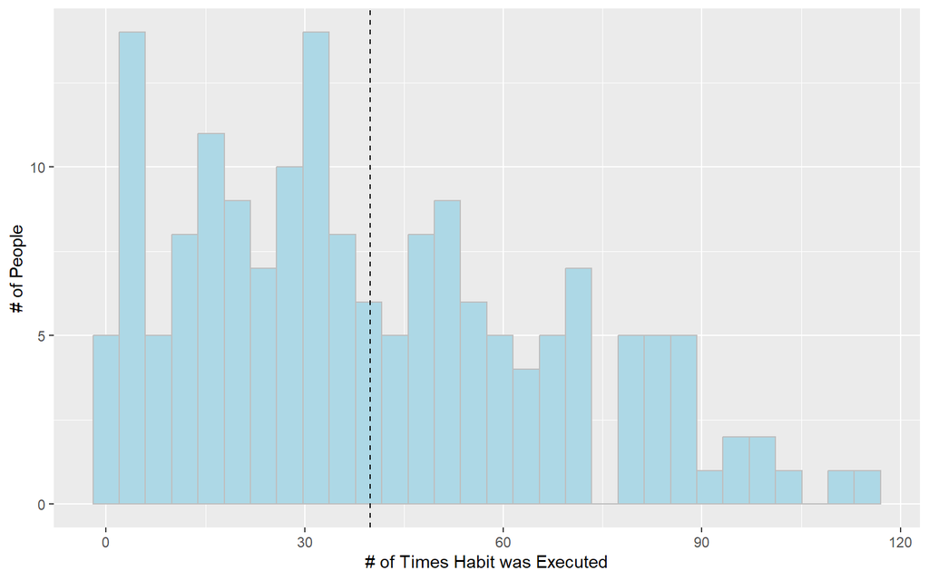

```r
d <- ggplot(data = dailyCounts1, aes(x = n))
d +geom_histogram(fill = 'lightblue', color = 'grey') + labs(x = "# of Times Habit was Executed", y = "# of People") + geom_vline(xintercept = mean(dailyCounts1$n, na.rm = TRUE), lty = 'dashed')
```

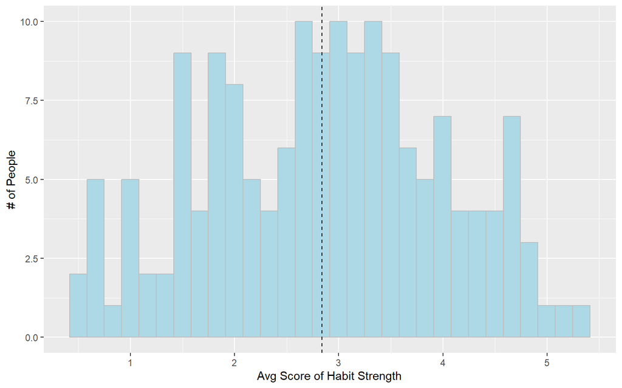

```r
h <- ggplot(data = habitReportsAVG, aes(x = pAVG))
h + geom_histogram(fill='lightblue',color = 'grey') + labs(x = "Avg Score of Habit Strength", y = "# of People") +  geom_vline(xintercept = mean(habitReportsAVG$pAVG, na.rm=TRUE), lty = 'dashed')
```

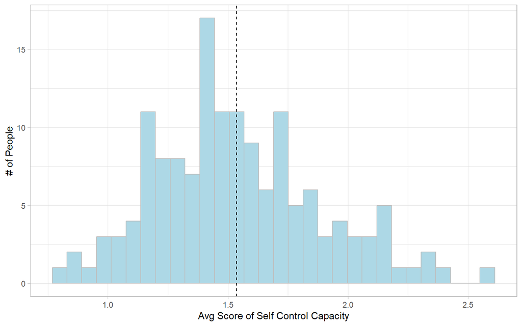

```r
s <- ggplot(data = selfControlAVG, aes(x = pAVG))
s + geom_histogram(fill = 'lightblue',color='grey') + labs( x = "Avg Score of Self Control Capacity", y = "# of People",) + theme_light() + geom_vline(xintercept = mean(selfControlAVG$pAVG, na.rm = TRUE), lty = 'dashed')
```

#### Citations

- van der Weiden A, Benjamins J, Gillebaart M, Ybema JF and de Ridder D (2020) How to Form Good Habits? A Longitudinal Field Study on the Role of Self-Control in Habit Formation. Front. Psychol. 11:560. doi: 10.3389/fpsyg.2020.00560